# 607 Week6 P3

Rajwant Mishra

March 6, 2019

[RpubLink](http://rpubs.com/Rajwantmishra/week6_607_p3of3)

## About Dataset

This data set list following variables of the heart patient with following variables:

```
 1. age
 2. sex
 3. chest pain type (4 values)
 4. resting blood pressure
 5. serum cholestoral in mg/dl
 6. fasting blood sugar > 120 mg/dl ( )
 7. resting electrocardiographic results (values 0,1,2)
 8. maximum heart rate achieved
 9. exercise induced angina
 10. oldpeak = STf the peak exercise ST segment
 12. number of depression induced by exercise relative to rest
 11. the slope o major vessels (0-3) colored by flourosopy
 13. thal: 3 = normal; 6 = fixed defect; 7 = reversable defec
 14. target 1= Probelm or 0 (NO Probelm )
```

### Read File

```r
# ageage in years
# sex(1 = male; 0 = female)
# cpchest pain type
# trestbpsresting blood pressure (in mm Hg on admission to the hospital)
# cholserum cholestoral in mg/dl
# fbs(fasting blood sugar > 120 mg/dl) (1 = true; 0 = false)
# restecg resting electrocardiographic results
# thalach maximum heart rate achieved
# exangexercise induced angina (1 = yes; 0 = no)
# oldpeakST depression induced by exercise relative to rest
# slopethe slope of the peak exercise ST segment
# canumber of major vessels (0-3) colored by flourosopy
# thal3 = normal; 6 = fixed defect; 7 = reversable defect
# target 1= Probelm or 0 (NO Probelm )



# ctype = c("numeric","factor","numeric","numeric","numeric", "boolean","numeric","numeric","boolean","double","numeric","numeric","numeric","boolean")
#
# ctype1 = c(col_integer(),col_logical(),col_integer(),col_integer(),col_integer(), col_logical(),col_integer(),col_integer(),col_logical(),col_double(),col_double(),col_double(),col_double(),col_logical())
#
# # "text","text","text","text","text","text","text")


hdata <- read_csv('https://raw.githubusercontent.com/Rajwantmishra/msds/master/607/Week6/data1/heart.csv',col_types = cols(
  age = col_double(),
  sex = col_factor(),
  cp = col_double(),
  trestbps = col_double(),
  chol = col_double(),
  fbs = col_logical(),
  restecg = col_double(),
  thalach = col_double(),
  exang = col_logical(),
  oldpeak = col_double(),
  slope = col_double(),
  ca = col_factor(),
  thal = col_factor(),
  target = col_logical())
)
datatable(hdata)
```

|  | age | sex | cp | trestbps | chol | fbs | restecg | thalach | exang | oldpeak | slope | ca | thal | target |
| --- | --- | --- | --- | --- | --- | --- | --- | --- | --- | --- | --- | --- | --- | --- |
| 1 | 63 | 1 | 3 | 145 | 233 | True | 0 | 150 | False | 2.3 | 0 | 0 | 1 | True |
| 2 | 37 | 1 | 2 | 130 | 250 | False | 1 | 187 | False | 3.5 | 0 | 0 | 2 | True |
| 3 | 41 | 0 | 1 | 130 | 204 | False | 0 | 172 | False | 1.4 | 2 | 0 | 2 | True |
| 4 | 56 | 1 | 1 | 120 | 236 | False | 1 | 178 | False | 0.8 | 2 | 0 | 2 | True |
| 5 | 57 | 0 | 0 | 120 | 354 | False | 1 | 163 | True | 0.6 | 2 | 0 | 2 | True |
| 6 | 57 | 1 | 0 | 140 | 192 | False | 1 | 148 | False | 0.4 | 1 | 0 | 1 | True |
| 7 | 56 | 0 | 1 | 140 | 294 | False | 0 | 153 | False | 1.3 | 1 | 0 | 2 | True |
| 8 | 44 | 1 | 1 | 120 | 263 | False | 1 | 173 | False | 0 | 2 | 0 | 3 | True |
| 9 | 52 | 1 | 2 | 172 | 199 | True | 1 | 162 | False | 0.5 | 2 | 0 | 3 | True |
| 10 | 57 | 1 | 2 | 150 | 168 | False | 1 | 174 | False | 1.6 | 2 | 0 | 2 | True |

[output cut: 293 more lines]

### Entropy Function

Here I haev decided to find Entropy of Traget varible for each observation present in the dataset.

- Creating Function to calculate Entropy.
- Creating Function to Plot Entropy graph for each varaible in the dataset for evaluation.

#### Read Entropy

```r
entropy <- function(target) {
  freq <- table(target)/length(target)
  # vectorize
  vec <- as.data.frame(freq)[,2]
  #drop 0 to avoid NaN resulting from log2
  vec<-vec[vec>0]
  #compute entropy
  -sum(vec * log2(vec))
}
```

#### Entropy Graph Function

- Pass dataset with “Target” variable
- Pass dataset with ‘Target variable’ and the ‘Dependendt variable’ for which you want to find the Entropy agaist Target.

```r
EntropyGraph <- function(data,target,var = NA) {



   if (is.na(var)){

       #use ddply to compute e and p for each value of the feature
  for (i in 1:length(data)){
     if(names(data[i])==target){next}
      #Strip out rows where feature is NA
     data<-data[!is.na(data[,names(data[i])]),]
     dd_data<-ddply(data, names(data[i]), here(summarise), e=entropy(target), N=length(target))
     dd_data$p <- as.data.frame(prop.table(table(data[i])))[[2]]
      # assign(paste0("EPLT",names(data[i])),
      #        ddply(data, names(data[i]), here(summarise), e=entropy(target), N=length(target)))
      # print (names(data[i]))

    g <- ggplot(dd_data,aes(x=p,y= e,fill=get(names(data[i]))))
          g <- g+ geom_col(position = "dodge")
          g <- g+ ggtitle(paste("Entropy proportion of",names(data[i]), "for Target: ",target))
          g <- g +geom_text(aes(label = get(names(data[i]))),color="red")
          # g <- g +geom_text(aes(label = p),color="green",nudge_x = .5)
          g <- g+ ylab("Entropy") + xlab("Proportion")
          g <- g+  guides(fill=guide_legend(title=names(data[i])))
        # g <- g+ geom_rect(mapping=aes(xmin= median(p) ,xmax= max(p),ymin=0,ymax=max(e),color="green"),color="black", alpha=0.01)
           g <- g +    geom_rect(mapping=aes(xmin= .5,xmax=1,ymin=0,ymax=.5,color="green"),color="red", alpha=0)

        print(g)
    }

   }else{
           #use ddply to compute e and p for each value of the feature
      for (i in 1:length(data)){
        if(names(data[i])!=var){next}
          #Strip out rows where feature is NA
      data<-data[!is.na(data[,names(data[i])]),]
         dd_data<-ddply(data, names(data[i]), here(summarise), e=entropy(target), N=length(target))
         dd_data$p <- round(as.data.frame(prop.table(table(data[i])))[[2]],2)
          # assign(paste0("EPLT",names(data[i])),
          #        ddply(data, names(data[i]), here(summarise), e=entropy(target), N=length(target)))
          # print (names(data[i]))

         g <- ggplot(dd_data,aes(x=p,y= e,fill=get(names(data[i]))))
          g <- g+ geom_col(position = "dodge")
          g <- g+ ggtitle(paste("Entropy proportion of",names(data[i]), "for Target: ",target))
          #g <- g + geom_text(aes(label = get(names(data[i]))),                            color="white" , fill= "black",nudge_y = -0.02)
          g <- g + geom_label(aes(label = get(names(data[i]))), color="white", size=5, nudge_y = -0.02)
           g <- g +geom_text(aes(label = p),color="blue",nudge_x = .01, nudge_y= 0.04)
          g <- g+ ylab("Entropy") + xlab("Proportion")
          g <- g+ guides(fill=guide_legend(title=var))
          #g <- g+ geom_rect(mapping=aes(xmin= median(p) ,xmax= max(p),ymin=0,ymax=max(e),color="green"),color="black", alpha=0.01)
          g <- g +    geom_rect(mapping=aes(xmin= .5,xmax=1,ymin=0,ymax=.5,color="green"),color="red", alpha=0)
          #g <- g + geom_point(aes(shape=names(data[i]),color=names(data[i])))



        print(g)
      }

   }

 }
```

### Analysis

Based on dataset Lets check our data with following observations :

- Check how entropy is impacting when Target = False (No Heart Probelm)
- Check how Entropy is impacting when Target = TRUE (Heart Problem)

#### Full Data Entropy

- Calculate Entropy of full data Boundry of the rectangle shows how much imporatnt that value of the variable can be for the dataset.

Based on the graph I found two variable from `hdata` dataset *ca* and “*thal*” with high proportion of in data and with compartive Lower entropy . Our objective is to find value with lower entropy and high proportion.

- Inside the bar you see the value , and out side the bar you see probability of that in the dataset .

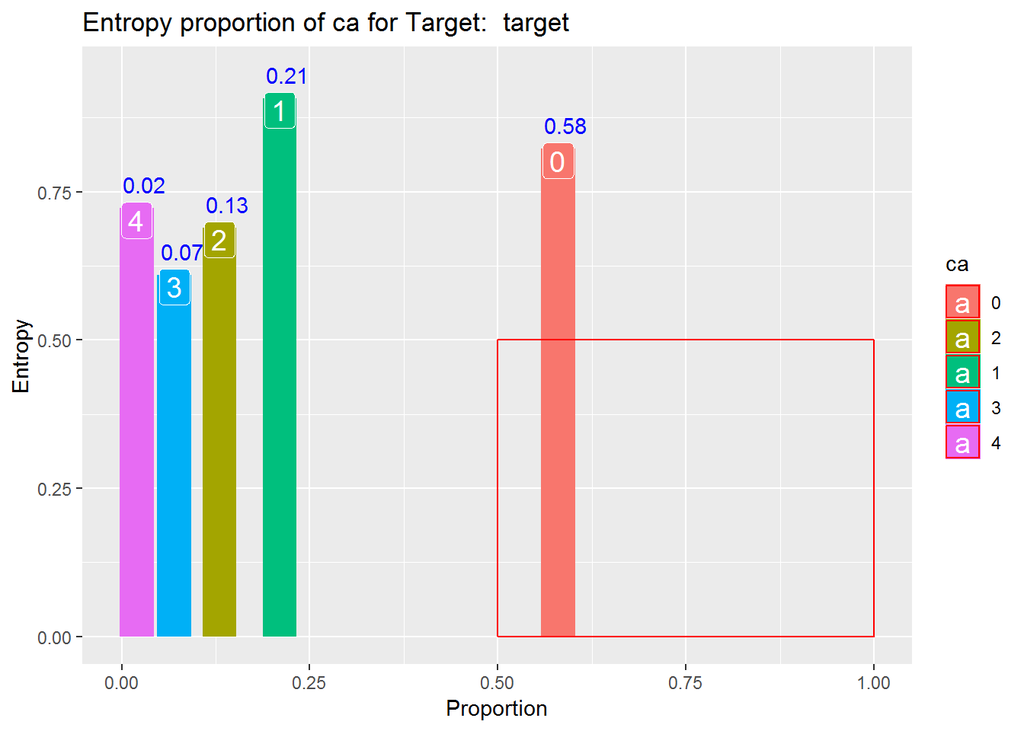

```r
# ***Below*** Commented to avoid big list of garph
 # EntropyGraph(hdata,"target")

 EntropyGraph(hdata,"target","ca")
```

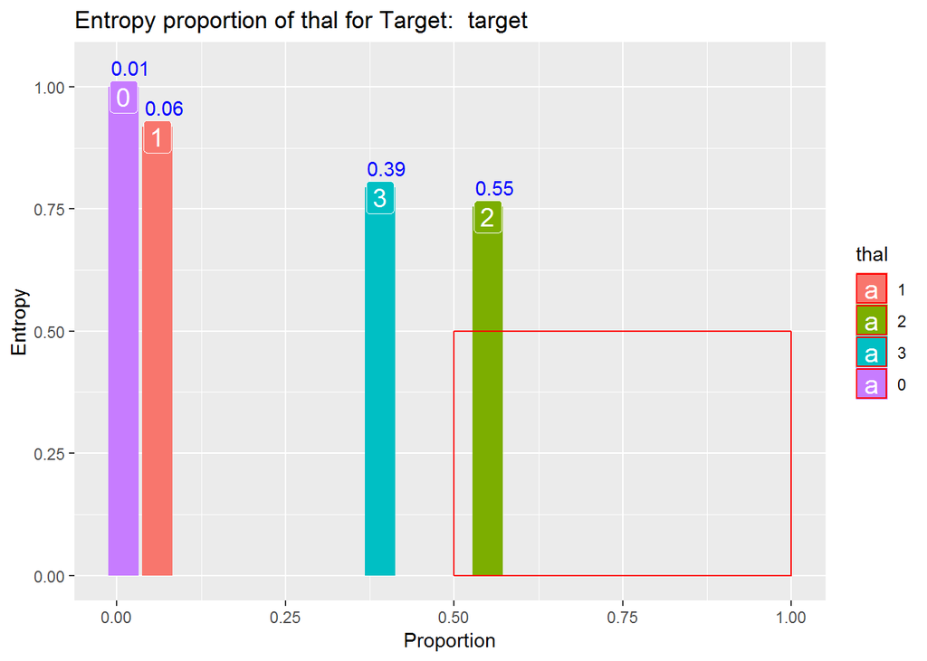

```r
 EntropyGraph(hdata,"target","thal")
```

#### TARGET = TRUE

Doing our analysis further on subset of data, Creating subset of data with Target == TRUE

> ```
>  Bases on below plots we can say that important variable to check Heart problem can be :
> ```

# slope = 2

# ca= 0

# thal = 2

# restecg = 1

```r
  hdataT <- filter(hdata,target==TRUE)
```

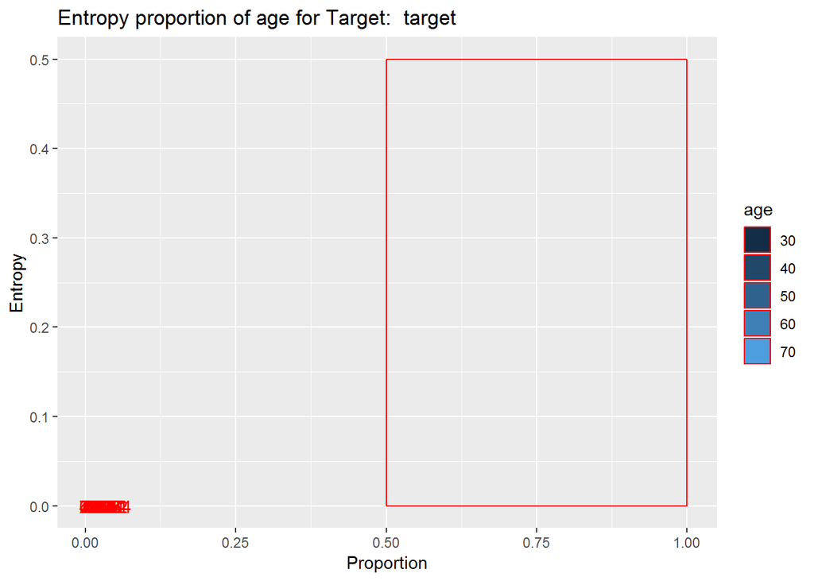

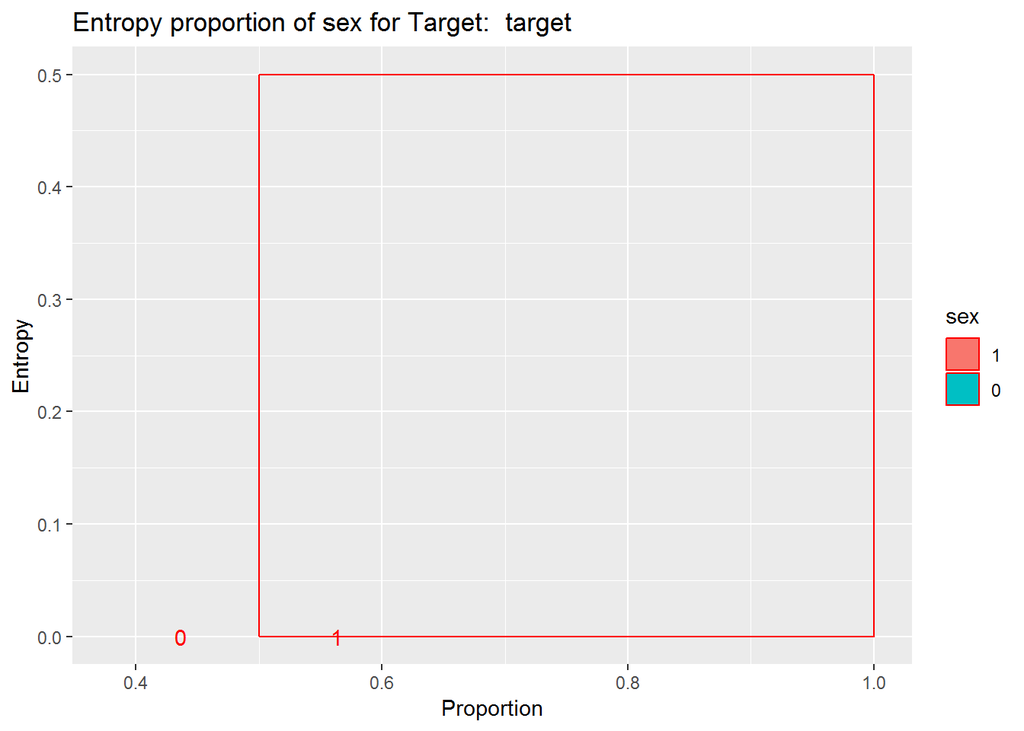

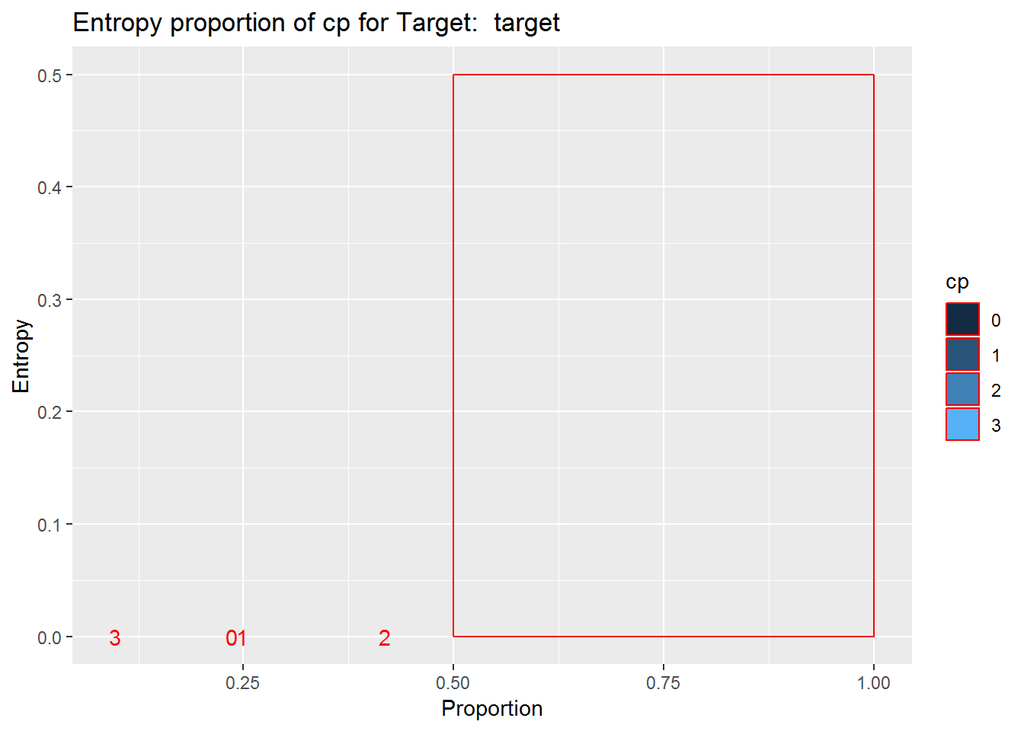

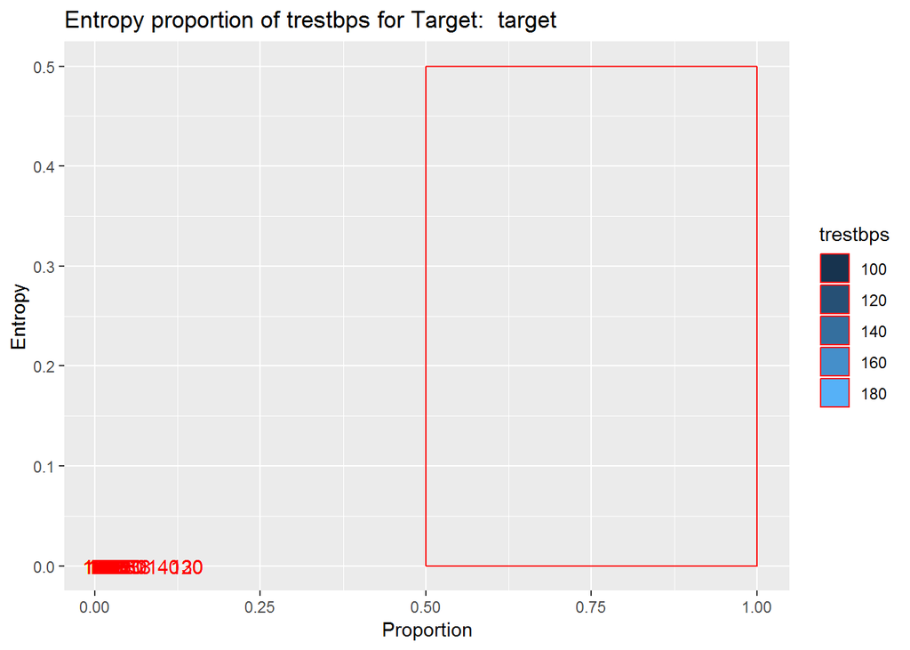

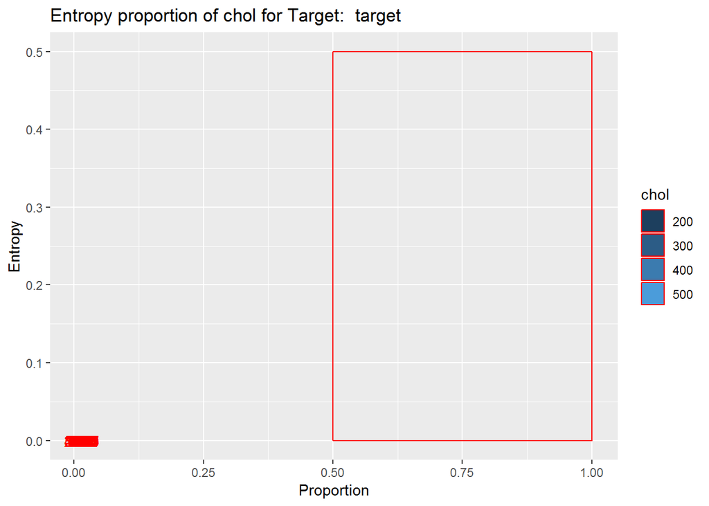

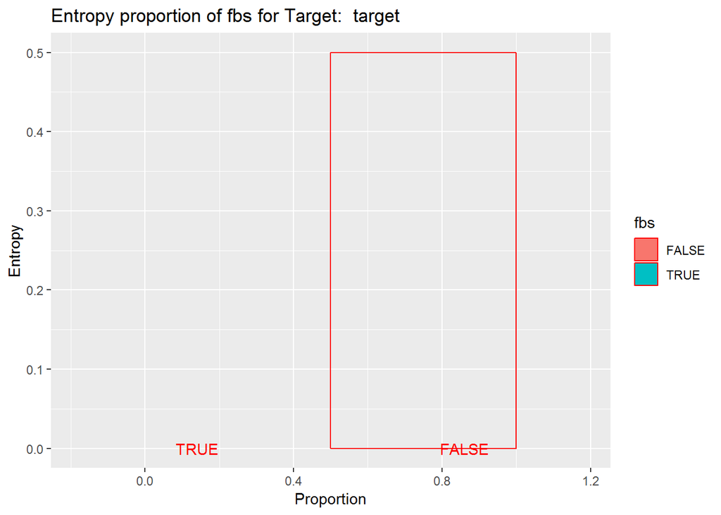

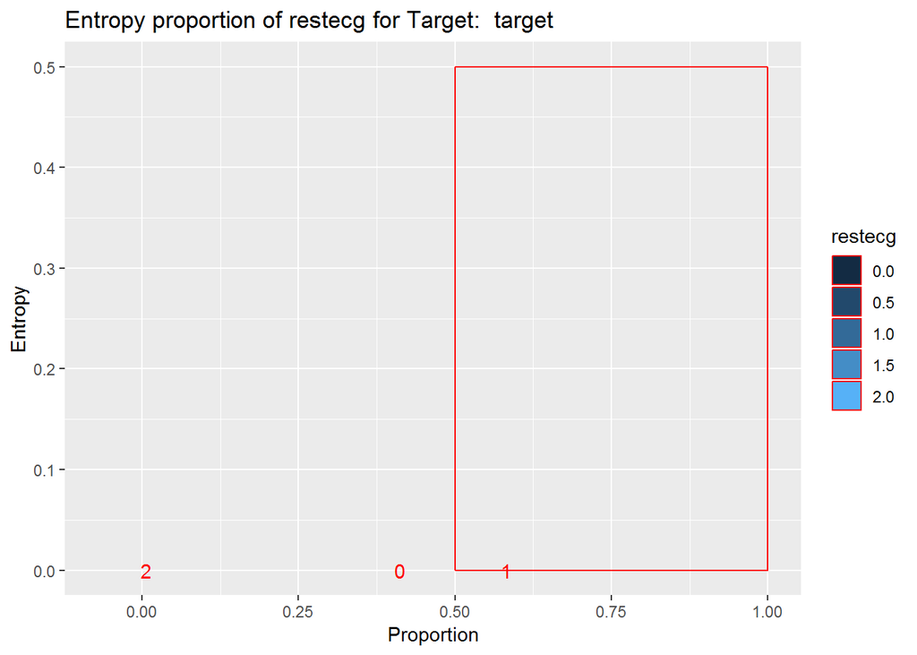

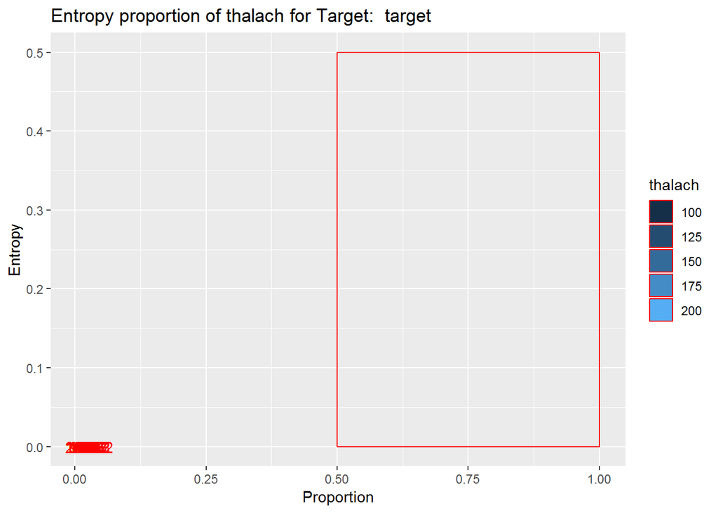

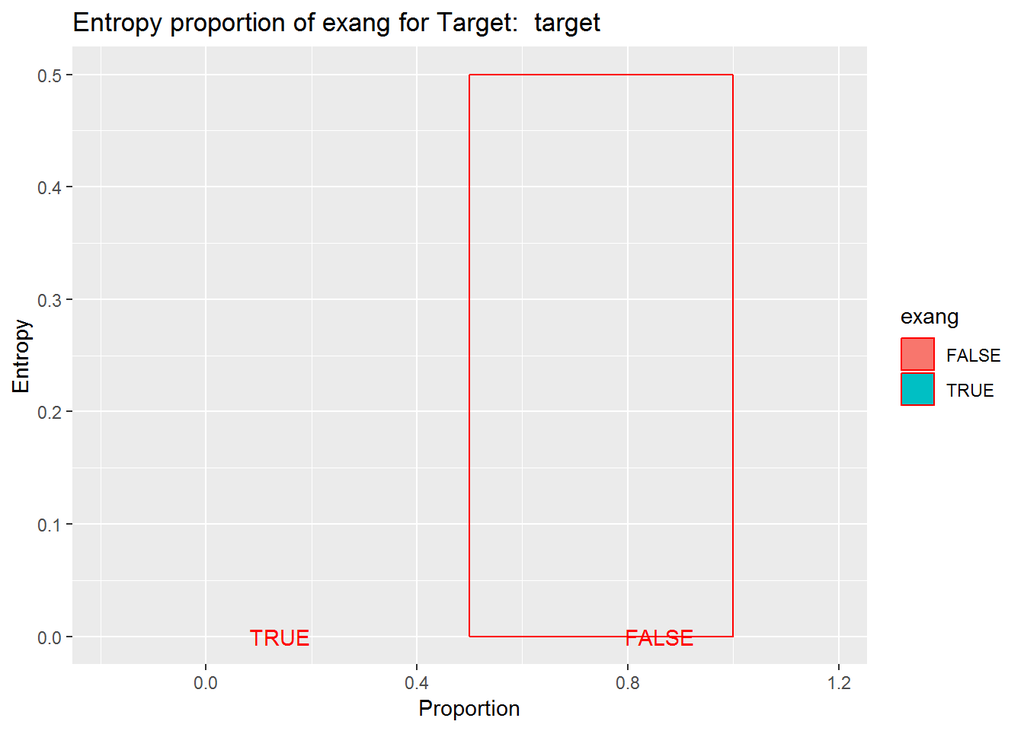

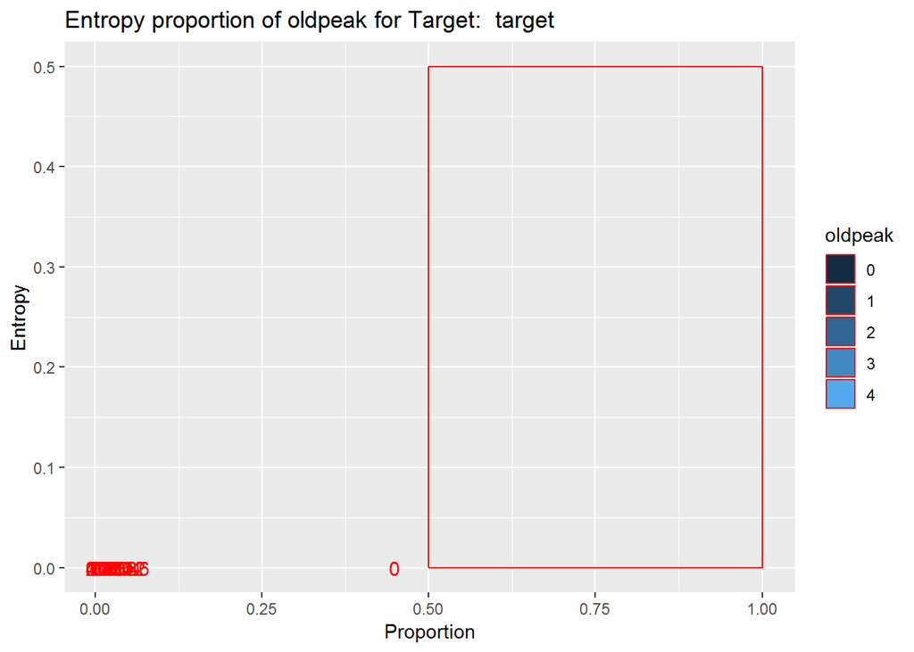

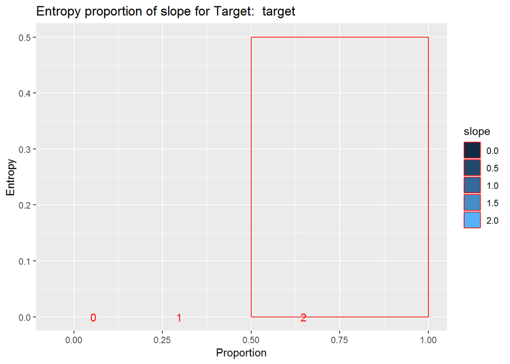

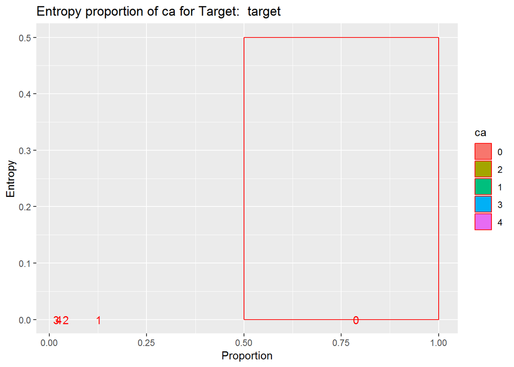

[1 more figures not shown]

```r
    EntropyGraph(hdataT,"target")
```

#### TARGET = FALSE

Creating subset of data with Target == FASLE

> Based on this data we can say that with following points we can have healthy heart. # FASLE # sex = 1 # cp = 0 # fbs = false # slop = 1 # thal = 3

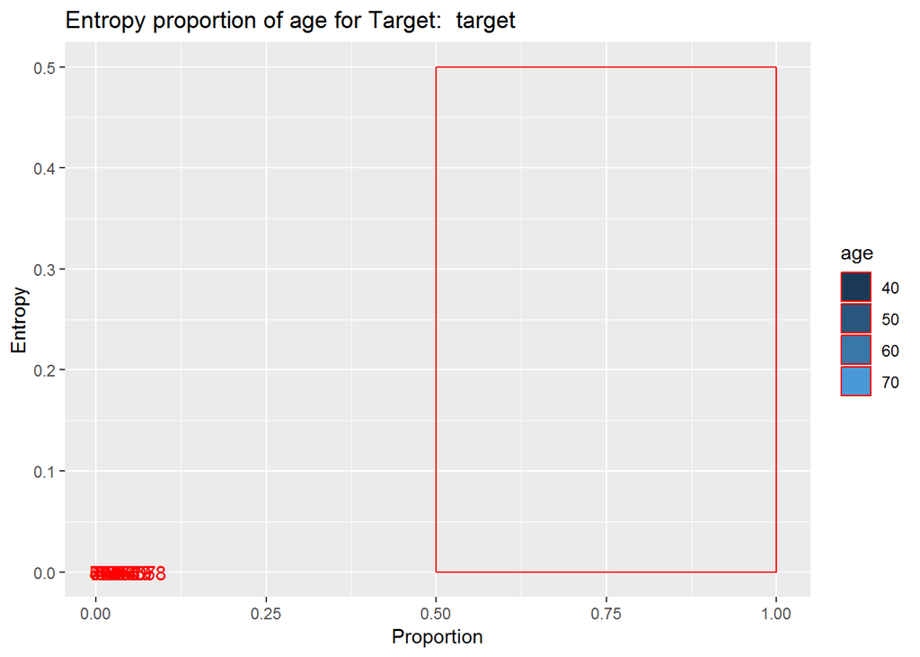

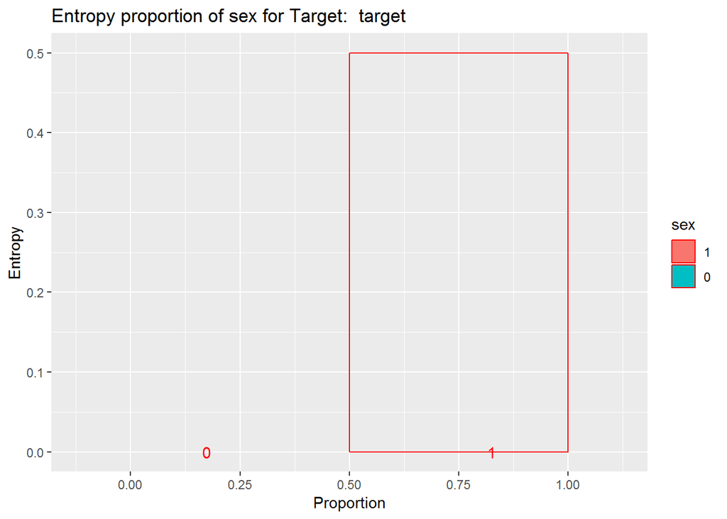

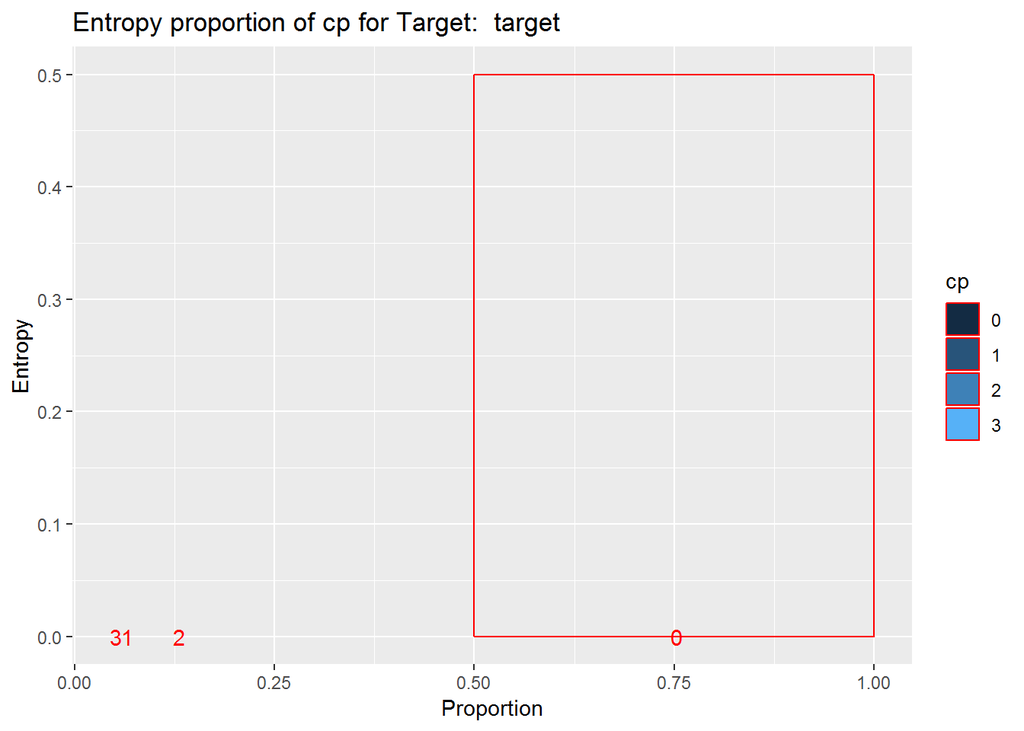

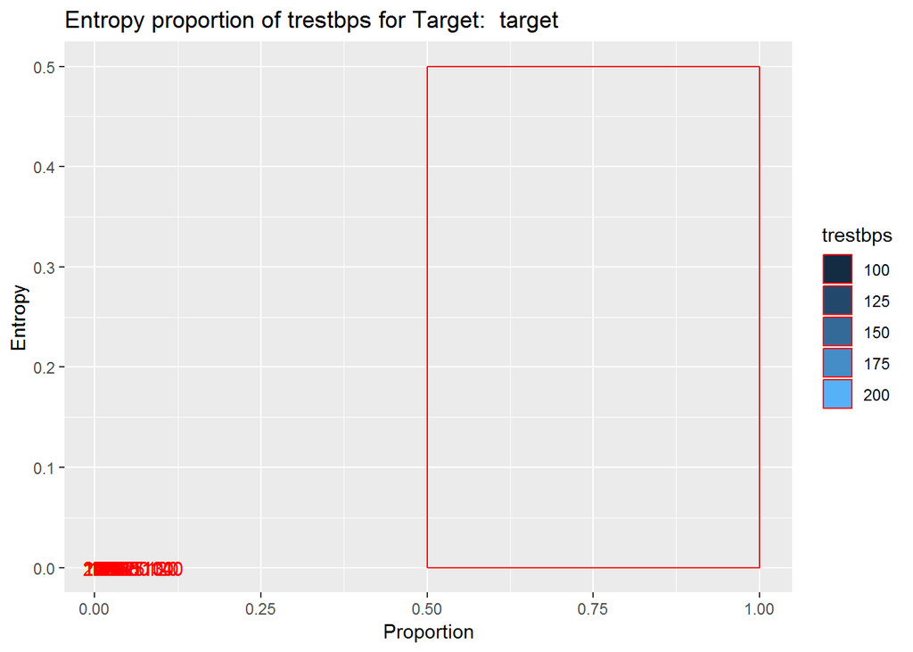

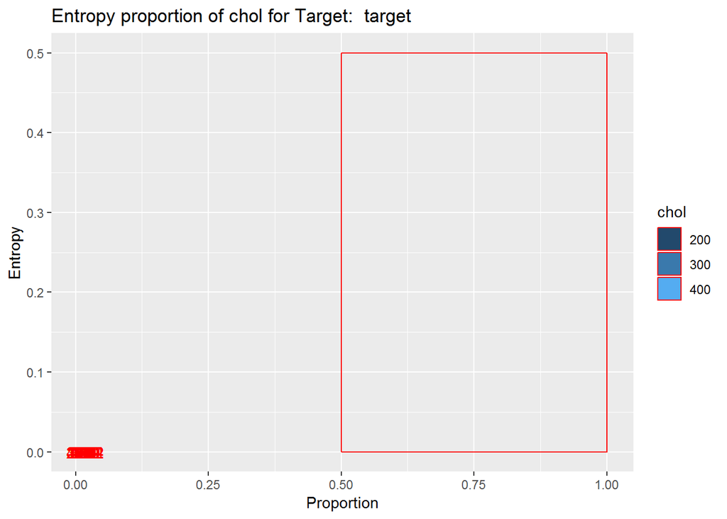

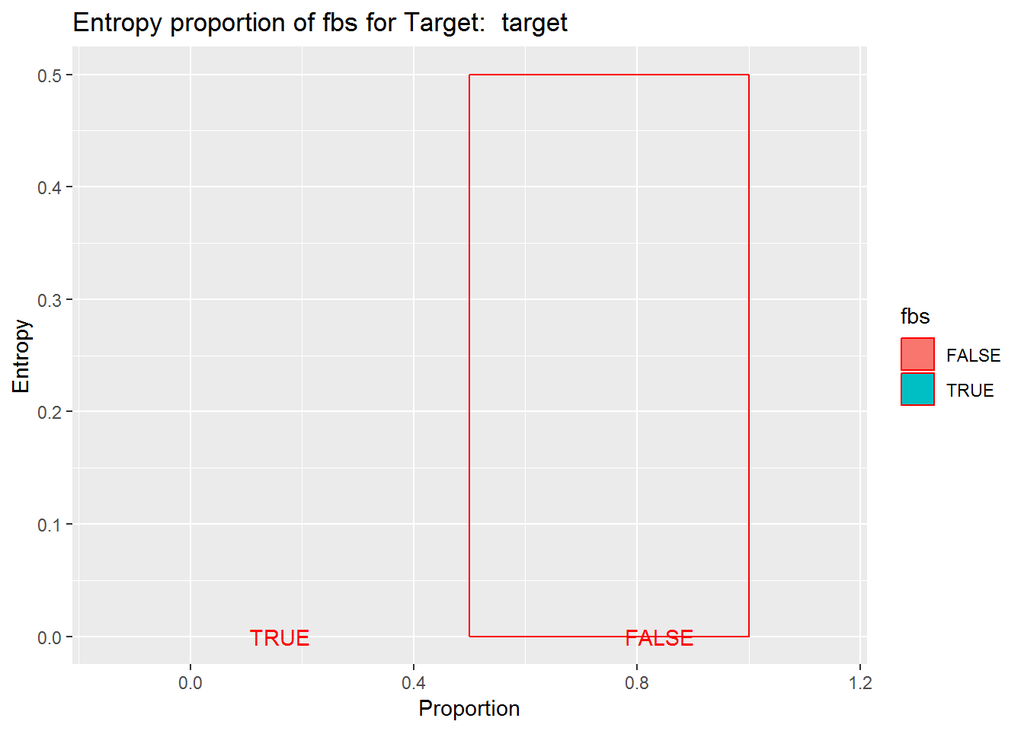

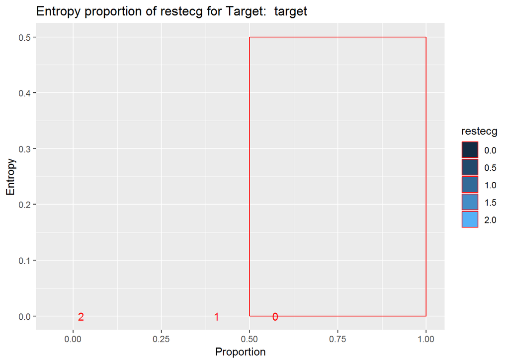

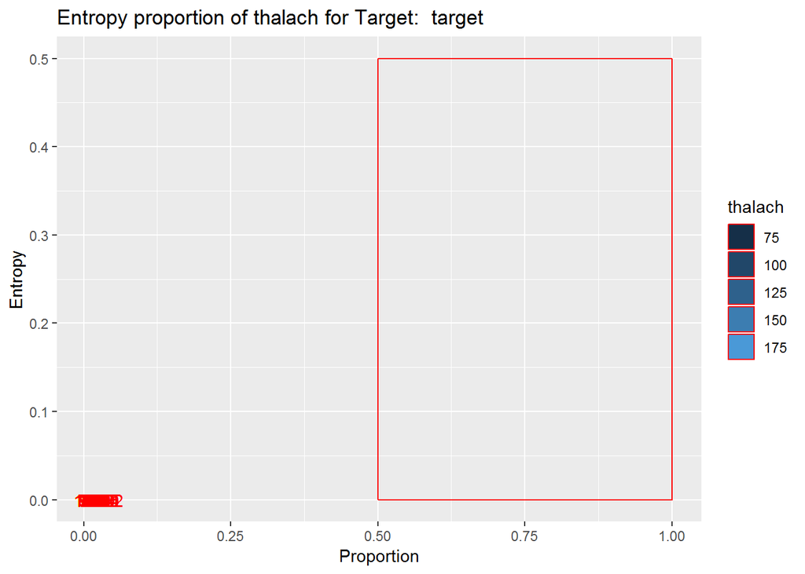

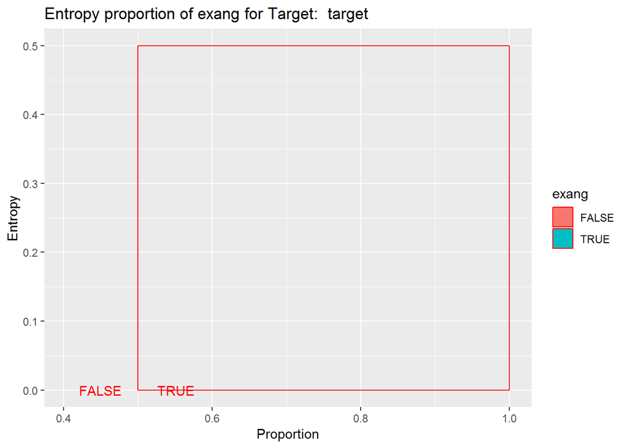

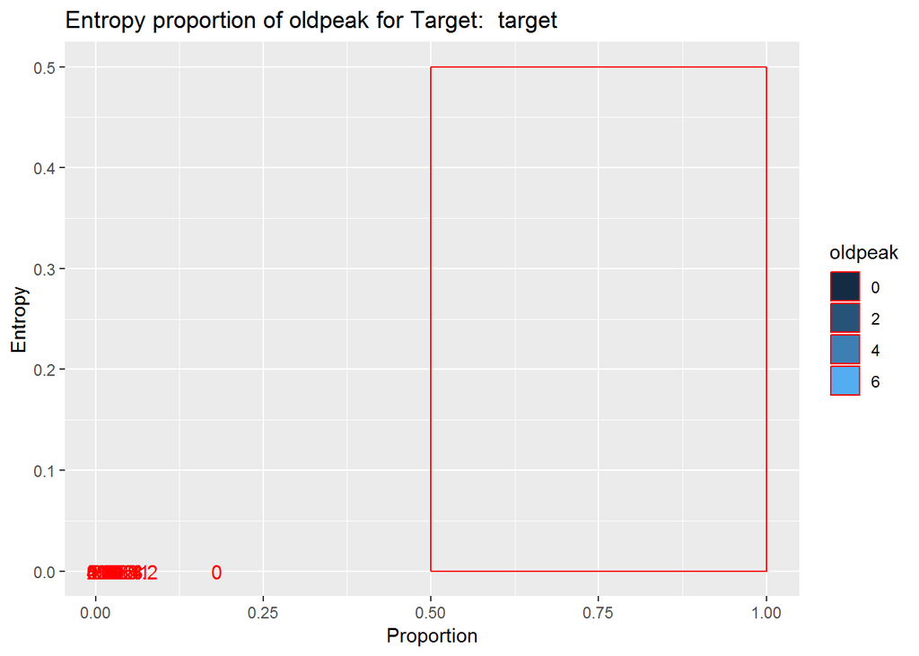

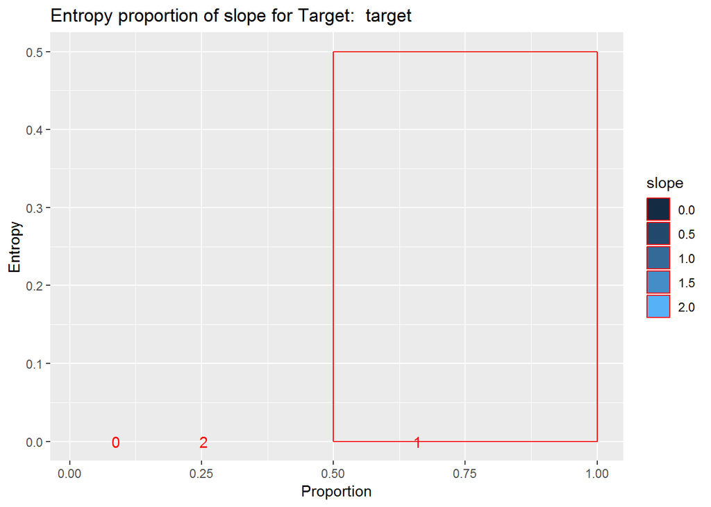

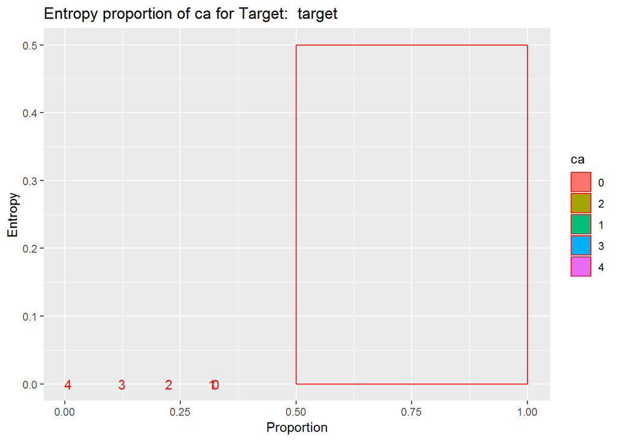

[1 more figures not shown]

```r
hdataF <- filter(hdata,target==FALSE)
EntropyGraph(hdataF,"target")
```

#### Subset Analysis

From Last two subset of data `hdataF` and `hdataT` we found some variables that can make some prediction about heart health condition.

**Attribute Information**

```
 1. age
 2. sex
 3. chest pain type (4 values)
 4. resting blood pressure
 5. serum cholestoral in mg/dl
 6. fasting blood sugar > 120 mg/dl ( )
 7. resting electrocardiographic results (values 0,1,2)
 8. maximum heart rate achieved
 9. exercise induced angina
 10. oldpeak = STf the peak exercise ST segment
 12. number of depression induced by exercise relative to rest
 11. the slope o major vessels (0-3) colored by flourosopy
 13. thal: 3 = normal; 6 = fixed defect; 7 = reversable defec
 14. target 1= Probelm or 0 (NO Probelm )
```

**Analysis for “FBS” : fasting blood sugar**

> FBS (fasting blood sugar) : it can be noted that FBS is not very imporant as it tends to show negative result with other varaibles . FBS is FALSE ~ 86% in population with heart probelm. Whereas in contrast its ~84% in case where heart probelm is not present. Even though entropy of this varible is not leading us to a pure mix of dataset, but avaibility of FBS in conjustion with other varaible can be used to predict right heart health condition.

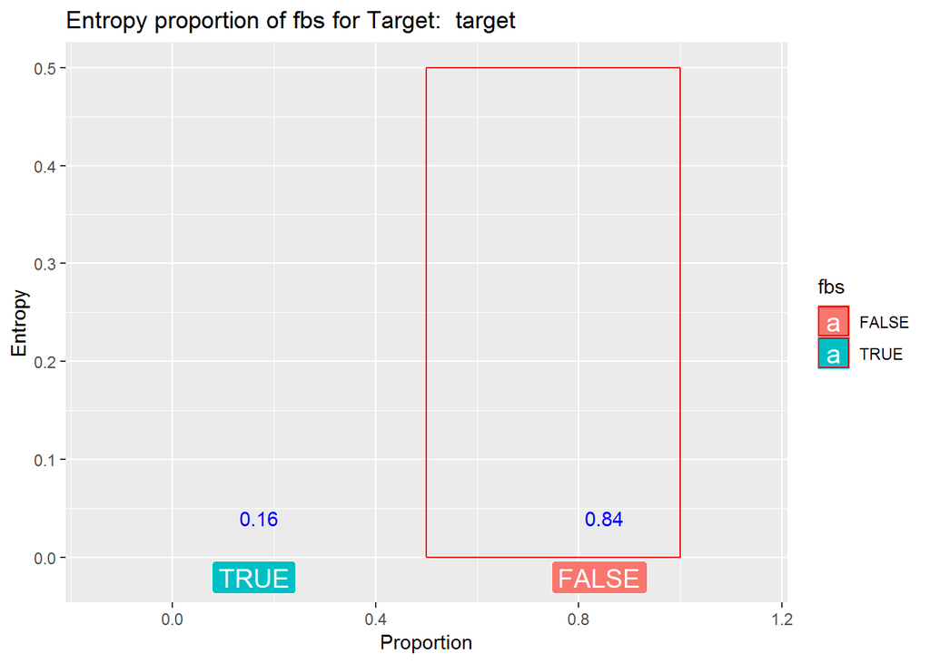

```r
# Lets take only TARGET = FALSE

    EntropyGraph(hdataF,"target","fbs")
```

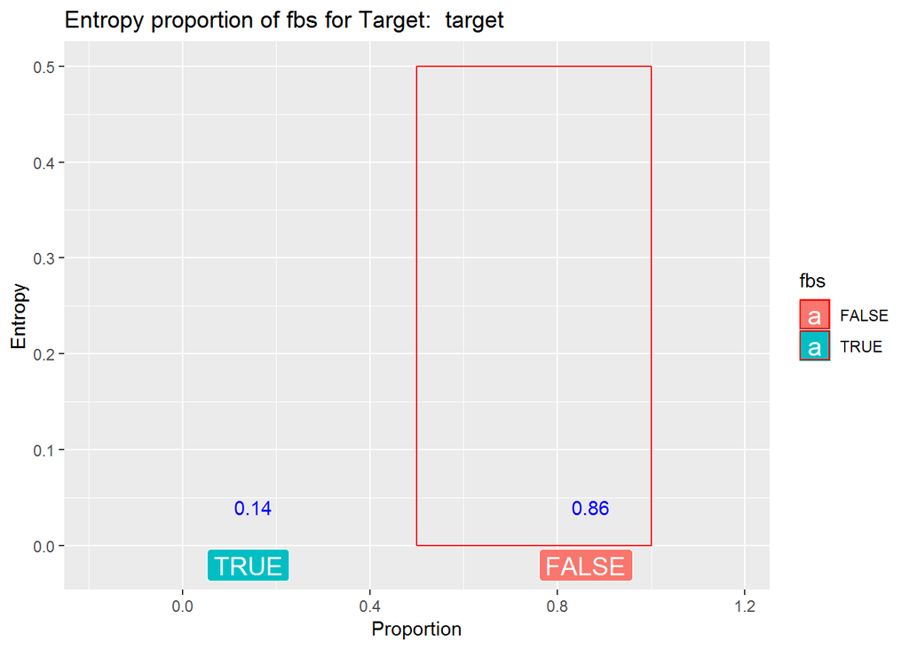

```r
    EntropyGraph(hdataT,"target","fbs")
```

**Analysis for “thal” : 3 = normal; 6 = fixed defect; 7 = reversable defect**

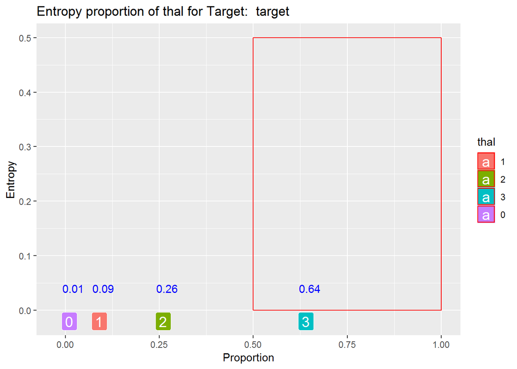

```r
# Lets break it further. checking thal

 EntropyGraph(hdataF,"target","thal")
```